# NYC Flights

## Setup

```r
library("knitr")
library("tidyverse")
library("nycflights13")
library("rnaturalearth")
library("sf")
library("rcartocolor")
library("scales")
library("scico")

theme_set(theme_minimal())
```

## Description of the data set

The `nycflights13` package contains 5 interlinked tables of airline on-time data for all flights departing NYC in 2013. The main table is called `flights`, which contains almost 337,000 rows. The four ‘metadata’ tables are called `airlines`, `airports`, `weather`, and `planes`.

## Spatial data for the maps

Let’s read in some spatial data using the `rnaturalearth` package. Review the maps activity and slides for a refresher. Specifically, we want the continental 48 states and the world at medium scale. We’ll also extract the bounding box for our new object called `states48` for easier plotting.

```r
states48 <- ne_states(iso_a2 = 'US', returnclass = "sf") |>
  filter(name != "Hawaii" & name != "Alaska")

world <- ne_countries(scale = "medium", returnclass = "sf")

my_bbox <- st_bbox(states48)
```

### Problem 1: Base map

Let’s create a basic map that will become the template for all our plots below.

```r
basic_map +
  geom_point(...) # or whatever
```

## Number of flights by destination

First, let’s show the number of flights departing NYC for each destination city.

### Problem 2: Preparing the data

Using the `flights` and `airports` tables, create a new data set called `airports_n` that includes the number of flights to each destination and all the airport metadata from the `airports` table (including `lat` adn `lon`).

| dest | n | name | lat | lon | alt | tz | dst | tzone |
| --- | --- | --- | --- | --- | --- | --- | --- | --- |
| ABQ | 254 | Albuquerque International Sunport | 35.04022 | -106.60919 | 5355 | -7 | A | America/Denver |
| ACK | 265 | Nantucket Mem | 41.25305 | -70.06018 | 48 | -5 | A | America/New_York |
| ALB | 439 | Albany Intl | 42.74827 | -73.80169 | 285 | -5 | A | America/New_York |
| ANC | 8 | Ted Stevens Anchorage Intl | 61.17436 | -149.99636 | 152 | -9 | A | America/Anchorage |
| ATL | 17215 | Hartsfield Jackson Atlanta Intl | 33.63672 | -84.42807 | 1026 | -5 | A | America/New_York |
| AUS | 2439 | Austin Bergstrom Intl | 30.19453 | -97.66989 | 542 | -6 | A | America/Chicago |

### Problem 3: Mapping the destination data

Create the map using a **bubble chart** to make the size of the point proportional to the number of flights. A few notes on styling:

- Try combining your legends for fill (or color) and size. I gave an example of how to do this when we plotted hurricane Katrina’s windspeed across the Gulf of Mexico (see the Geospatial section).
- Use `labels = scales::label_comma()` in your scale function to get nicely formatted labels.

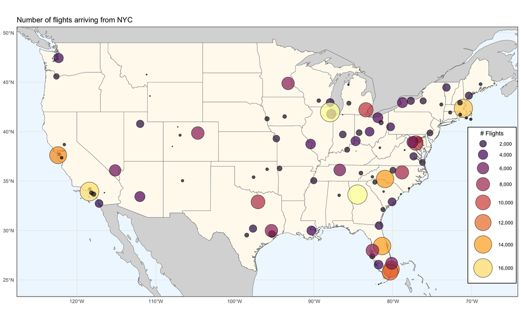

### Problem 4: Mapping average arrival delays for flights from NYC.

Using the `flights` and `airports` tables, create a new data set called `avg_delay` that calculates the average arrival delay (`arr_delay`) then bring in all the airport metadata from the `airports` table (including `lat` adn `lon`).

| dest | mean_delay | name | lat | lon | alt | tz | dst | tzone |
| --- | --- | --- | --- | --- | --- | --- | --- | --- |
| ABQ | 4.381890 | Albuquerque International Sunport | 35.04022 | -106.60919 | 5355 | -7 | A | America/Denver |
| ACK | 4.852273 | Nantucket Mem | 41.25305 | -70.06018 | 48 | -5 | A | America/New_York |
| ALB | 14.397129 | Albany Intl | 42.74827 | -73.80169 | 285 | -5 | A | America/New_York |
| ANC | -2.500000 | Ted Stevens Anchorage Intl | 61.17436 | -149.99636 | 152 | -9 | A | America/Anchorage |
| ATL | 11.300113 | Hartsfield Jackson Atlanta Intl | 33.63672 | -84.42807 | 1026 | -5 | A | America/New_York |
| AUS | 6.019909 | Austin Bergstrom Intl | 30.19453 | -97.66989 | 542 | -6 | A | America/Chicago |

Create the map by using points that are colored/filled by the average delay for that city. I used the palette `vik` from the `scico` package, which allows you to set a midpoint for asymetric diverging color palettes.

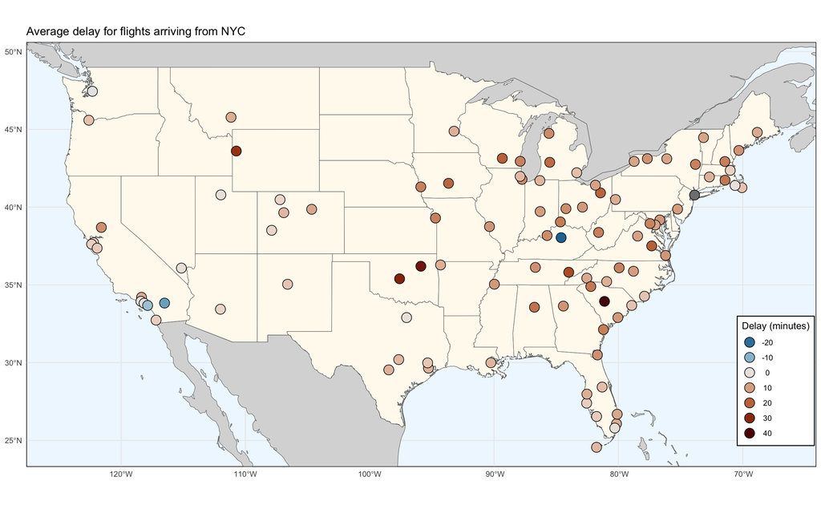

### Problem 5: Mapping 100 routes at random.

In this activity, we want to draw (approximately) the route each plane flies from its origin to its destination for the 100 flights drawn randomly from the entire set. We want to color these routes by the carrier’s full name (e.g., “Delta Air Lines Inc.”). What variables would you need? What tables would you need to combine?

Let’s call this new data set `rand_flights`. Use the `dplyr` function `sample_n()` to select 100 rows at random.

```
Rows: 100
Columns: 24
$ year           <int> 2013, 2013, 2013, 2013, 2013, 2013, 2013, 2013, 2013, 2…
$ month          <int> 6, 12, 9, 8, 2, 7, 9, 5, 3, 9, 8, 6, 6, 4, 5, 4, 9, 2, …
$ day            <int> 23, 29, 3, 25, 21, 6, 23, 12, 17, 12, 7, 22, 14, 22, 31…
$ dep_time       <int> 618, 740, 1259, 720, 559, 1806, 1005, 1805, 2045, 605, …
$ sched_dep_time <int> 620, 740, 1250, 720, 605, 1730, 931, 1745, 2040, 608, 6…
$ dep_delay      <dbl> -2, 0, 9, 0, -6, 36, 34, 20, 5, -3, -5, -10, -9, 11, -2…
$ arr_time       <int> 840, 908, 1402, 811, 802, 2039, 1308, 2125, 2154, 728, …
$ sched_arr_time <int> 843, 925, 1359, 845, 805, 2042, 1235, 2031, 2148, 737, …
$ arr_delay      <dbl> -3, -17, 3, -34, -3, -3, 33, 54, 6, -9, -25, -5, -11, 1…
$ carrier        <chr> "DL", "AA", "B6", "WN", "MQ", "DL", "B6", "B6", "B6", "…
$ flight         <int> 1743, 307, 316, 1705, 4401, 1435, 271, 527, 1178, 1622,…
$ tailnum        <chr> "N643DL", "N3KUAA", "N190JB", "N956WN", "N722MQ", "N960…
$ origin         <chr> "JFK", "LGA", "JFK", "EWR", "LGA", "LGA", "LGA", "EWR",…
$ dest           <chr> "ATL", "ORD", "SYR", "BNA", "DTW", "TPA", "FLL", "MCO",…
$ air_time       <dbl> 114, 121, 46, 92, 100, 132, 136, 154, 40, 117, 178, 45,…
$ distance       <dbl> 760, 733, 209, 748, 502, 1010, 1076, 937, 200, 719, 141…
$ hour           <dbl> 6, 7, 12, 7, 6, 17, 9, 17, 20, 6, 6, 23, 13, 16, 17, 20…
$ minute         <dbl> 20, 40, 50, 20, 5, 30, 31, 45, 40, 8, 30, 0, 9, 16, 0, …
$ time_hour      <dttm> 2013-06-23 06:00:00, 2013-12-29 07:00:00, 2013-09-03 1…
$ origin_lat     <dbl> 40.63975, 40.77725, 40.63975, 40.69250, 40.77725, 40.77…
$ origin_lon     <dbl> -73.77893, -73.87261, -73.77893, -74.16867, -73.87261, …
$ dest_lat       <dbl> 33.63672, 41.97860, 43.11119, 36.12447, 42.21244, 27.97…
$ dest_lon       <dbl> -84.42807, -87.90484, -76.10631, -86.67819, -83.35339, …
$ name           <chr> "Delta Air Lines Inc.", "American Airlines Inc.", "JetB…
```

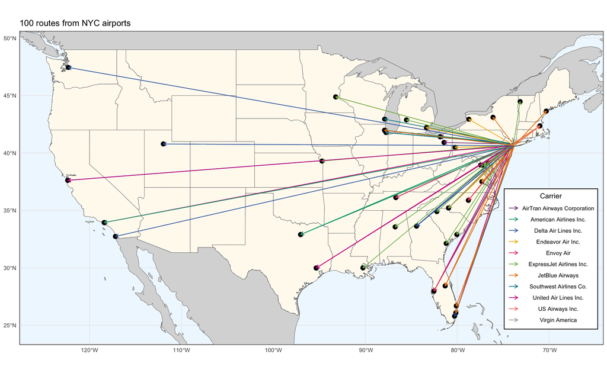